# IODS course project

Scaling the data

```r
# center and standardize variables
boston_scaled <- scale(Boston)

# summaries of the scaled variables
summary(boston_scaled)
```

```
##       crim                 zn               indus              chas
##  Min.   :-0.419367   Min.   :-0.48724   Min.   :-1.5563   Min.   :-0.2723
##  1st Qu.:-0.410563   1st Qu.:-0.48724   1st Qu.:-0.8668   1st Qu.:-0.2723
##  Median :-0.390280   Median :-0.48724   Median :-0.2109   Median :-0.2723
##  Mean   : 0.000000   Mean   : 0.00000   Mean   : 0.0000   Mean   : 0.0000
##  3rd Qu.: 0.007389   3rd Qu.: 0.04872   3rd Qu.: 1.0150   3rd Qu.:-0.2723
##  Max.   : 9.924110   Max.   : 3.80047   Max.   : 2.4202   Max.   : 3.6648
##       nox                rm               age               dis
##  Min.   :-1.4644   Min.   :-3.8764   Min.   :-2.3331   Min.   :-1.2658
##  1st Qu.:-0.9121   1st Qu.:-0.5681   1st Qu.:-0.8366   1st Qu.:-0.8049
##  Median :-0.1441   Median :-0.1084   Median : 0.3171   Median :-0.2790
##  Mean   : 0.0000   Mean   : 0.0000   Mean   : 0.0000   Mean   : 0.0000
##  3rd Qu.: 0.5981   3rd Qu.: 0.4823   3rd Qu.: 0.9059   3rd Qu.: 0.6617
##  Max.   : 2.7296   Max.   : 3.5515   Max.   : 1.1164   Max.   : 3.9566
##       rad               tax             ptratio            black
##  Min.   :-0.9819   Min.   :-1.3127   Min.   :-2.7047   Min.   :-3.9033
##  1st Qu.:-0.6373   1st Qu.:-0.7668   1st Qu.:-0.4876   1st Qu.: 0.2049
##  Median :-0.5225   Median :-0.4642   Median : 0.2746   Median : 0.3808
##  Mean   : 0.0000   Mean   : 0.0000   Mean   : 0.0000   Mean   : 0.0000
##  3rd Qu.: 1.6596   3rd Qu.: 1.5294   3rd Qu.: 0.8058   3rd Qu.: 0.4332
##  Max.   : 1.6596   Max.   : 1.7964   Max.   : 1.6372   Max.   : 0.4406
##      lstat              medv
##  Min.   :-1.5296   Min.   :-1.9063
##  1st Qu.:-0.7986   1st Qu.:-0.5989
##  Median :-0.1811   Median :-0.1449
##  Mean   : 0.0000   Mean   : 0.0000
##  3rd Qu.: 0.6024   3rd Qu.: 0.2683
##  Max.   : 3.5453   Max.   : 2.9865
```

```r
# class of the boston_scaled object
class(boston_scaled)
```

```
## [1] "matrix" "array"
```

```r
# change the object to data frame
boston_scaled<- as.data.frame(boston_scaled)
```

Let us create test and train sets

```r
# quantile vector crim
bins <- quantile(boston_scaled$crim)
bins
```

```
##           0%          25%          50%          75%         100%
## -0.419366929 -0.410563278 -0.390280295  0.007389247  9.924109610
```

```r
# Create a categorical variable 'crime':
crime <- cut(boston_scaled$crim, breaks = bins, include.lowest = TRUE, label = c("low","med_low","med_high","high"))

# Remove original 'crim' from the dataset:
boston_scaled <- dplyr::select(boston_scaled, -crim)

# Add the new categorical value 'crime' to scaled data
boston_scaled <- data.frame(boston_scaled, crime)

# choose randomly 80% of the rows:
n <- nrow(boston_scaled)
ind <- sample(n,  size = n * 0.8)

# create train and test sets:
train <- boston_scaled[ind,]
test <- boston_scaled[-ind,]
```

Linear Discriminant Analysis(LDA)

Here let’s consider Crime as target variable and other variables as predictor variables

```r
# linear discriminant analysis
lda.fit <- lda(crime ~., data = train)
lda.fit
```

```
## Call:
## lda(crime ~ ., data = train)
##
## Prior probabilities of groups:
##       low   med_low  med_high      high
## 0.2425743 0.2549505 0.2549505 0.2475248
##
## Group means:
##                  zn      indus         chas        nox         rm        age
## low       0.8940161 -0.9200816 -0.111631099 -0.8517352  0.4369353 -0.9168603
## med_low  -0.1306939 -0.2547609 -0.004759149 -0.5253859 -0.1634850 -0.3358065
## med_high -0.3773415  0.2218910  0.262810770  0.4176993  0.0752479  0.4374749
## high     -0.4872402  1.0171519  0.003267949  1.1018942 -0.3420702  0.8469649
##                 dis        rad        tax     ptratio       black       lstat
## low       0.9146748 -0.6994421 -0.7267969 -0.39706091  0.37365413 -0.77772436
## med_low   0.2570274 -0.5592799 -0.4736030 -0.05076457  0.36020750 -0.12716762
## med_high -0.3903740 -0.4143278 -0.3029742 -0.37409834  0.06903107  0.04265566
## high     -0.8639644  1.6377820  1.5138081  0.78037363 -0.76362709  0.91346878
##                  medv
## low       0.508461936
## med_low   0.003294567
## med_high  0.168817331
## high     -0.716617564
##
## Coefficients of linear discriminants:
##                 LD1          LD2         LD3
## zn       0.13430901  0.677460277 -0.82142879
## indus    0.02260023 -0.274457049  0.29194881
## chas    -0.08198317 -0.043211870  0.07410817
## nox      0.36015718 -0.601901522 -1.41051307
## rm      -0.08206215  0.004344475 -0.15643922
## age      0.28191616 -0.397798052 -0.26143758
## dis     -0.06037916 -0.240647058 -0.18732633
## rad      3.20268730  0.850447218 -0.02899601
## tax     -0.02170175 -0.009313910  0.48558992
## ptratio  0.11519454  0.125697682 -0.23880589
## black   -0.12683631  0.017356935  0.18741181
## lstat    0.23586398 -0.232571665  0.33528994
## medv     0.19209357 -0.438634682 -0.28109545
##
## Proportion of trace:
##    LD1    LD2    LD3
## 0.9502 0.0372 0.0126
```

Lets plot LDA

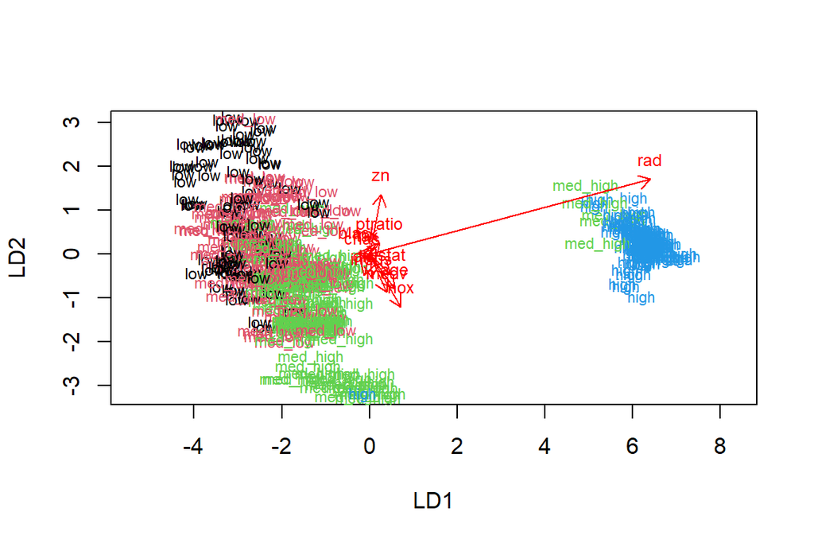

```r
# The function for LDA biplot arrows
lda.arrows <- function(x, myscale = 1, arrow_heads = 0.1, color = "red", tex = 0.75, choices = c(1,2)){
  heads <- coef(x)
  arrows(x0 = 0, y0 = 0,
         x1 = myscale * heads[,choices[1]],
         y1 = myscale * heads[,choices[2]], col=color, length = arrow_heads)
  text(myscale * heads[,choices], labels = row.names(heads),
       cex = tex, col=color, pos=3)
}
# target classes as numeric
classes <- as.numeric(train$crime)
# plotting the lda results and adding arrows
plot(lda.fit, dimen = 2, col = classes, pch = classes)
lda.arrows(lda.fit, myscale = 2)
```

The above plot explains that LD1 classifies well the group having high crime rate.There is a cluster formed in the right side.

Rad seems significant variable.

Eventhough LD2 clearly differs between low, med-low, med-high crime rate it cannot clearly form clustors.

```r
# Save the correct classes from test data:
correct_classes <- test$crime

# Remove the crime variable from test data:
test <- dplyr::select(test, -crime)

# Predict classes with test data:
lda.pred <- predict(lda.fit, newdata = test)

# Cross-tabulate the results:
table(correct = correct_classes, predicted = lda.pred$class)
```

```
##           predicted
## correct    low med_low med_high high
##   low       20       8        1    0
##   med_low    5      15        3    0
##   med_high   0       8       14    1
##   high       0       0        0   27
```

Above result shows the model can predict the high crime rate suburbs with high accuracy It seems difficult to find the difference between med_low and med_high

K means clustering

Reload and standardize Boston data

```r
data("Boston")
boston_scaled <- scale(Boston)
boston_scaled=as.data.frame(boston_scaled)
class(boston_scaled)
```

```
## [1] "data.frame"
```

```r
#Calculate distance matrix between observations
dist_eu <- dist(boston_scaled)

summary(dist_eu)
```

```
##    Min. 1st Qu.  Median    Mean 3rd Qu.    Max.
##  0.1343  3.4625  4.8241  4.9111  6.1863 14.3970
```

Now lets build K means clustoring with this scaled Boston data

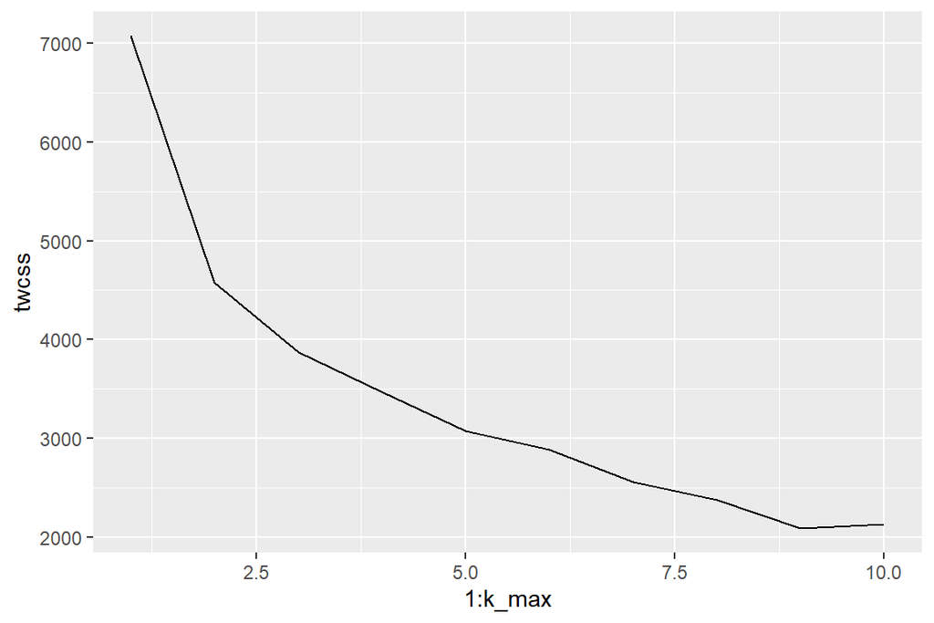

```r
k_max <- 10

# calculate the total within sum of squares
twcss <- sapply(1:k_max, function(k){kmeans(boston_scaled, k)$tot.withinss})

# visualize the results
qplot(x = 1:k_max, y = twcss, geom = 'line')
```

Let us consider 2 clusters

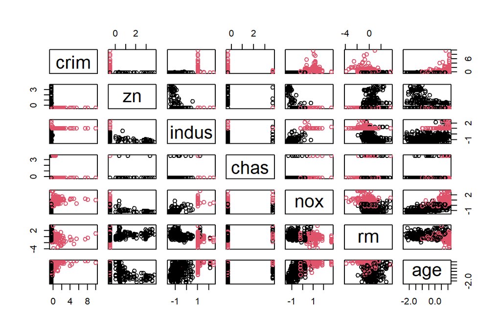

```r
# k-means clustering
km <-kmeans(boston_scaled, centers = 2)

# plot the Boston dataset with clusters
pairs(boston_scaled[1:7], col = km$cluster)
```

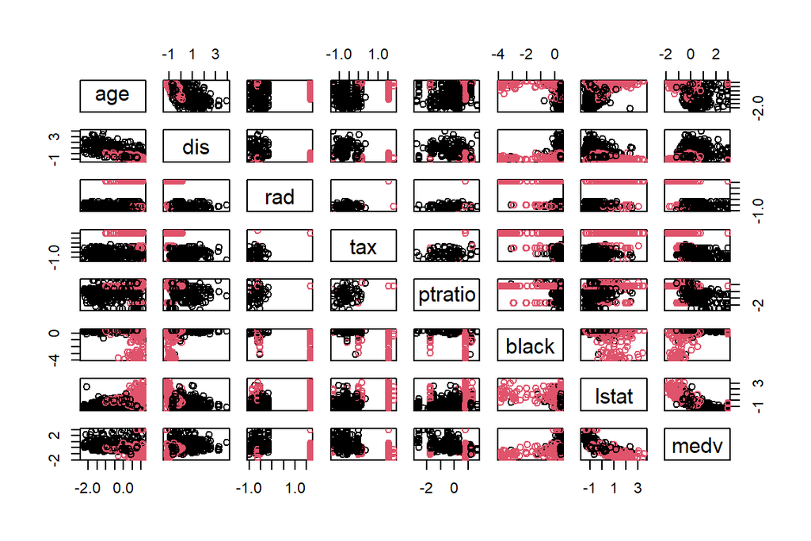

```r
pairs(boston_scaled[7:14], col = km$cluster)
```

From above plots it is clear that some clusters clearly seperated , some are not. It clearly shows rad variable is most significant